# MitoPerturbSeq heteroplasmy analysis

Author

Abhilesh Dhawanjewar

Published

November 27, 2025

**Load and preprocess data**

```r
# Load data
mtDNA_data <- read.csv(
    here(data_dir, "integrated_dataset_metadata.csv"))
# There are 76 rows with heteroplasmy values as NAs

# Load mixscape data
mixscape_data <- read.csv(
    here(data_dir, "integrated_mixscape_metadata.csv"))

# This function predicts technical measurement variance based on mtDNA depth and is used for empirical weighting in linear models
het_sim_df <- readRDS(
    here(data_dir, "het_depth_sim.rds")
)
get_measurement_variance <- readRDS(
    here(data_dir, "measurement_variance_function.rds")
)

# Change labels for "Park2" and "Nontargeting"
mtDNA_data$top_guide_final_enrich_combined <-   mtDNA_data$top_guide_final_enrich_combined %>%
    replace(mtDNA_data$top_guide_final_enrich_combined == "Park2", "Prkn") %>%
    replace(mtDNA_data$top_guide_final_enrich_combined == "Nontargeting", "NT")

gRNA_order <- c(
        "Akap1",
        "Nnt",
        "Polg",
        "Tfam",
        "Dnm1l",
        "Mtfp1",
        "Opa1",
        "Snx9",
        "Atg5",
        "Oma1",
        "Pink1",
        "Ppargc1a",
        "Prkn",
        "Eomes",
        "Neurod1",
        "Olig1",
        "Opn4",
        "Rgr",
        "Rrh",
        "NT"
    )

# Order the factor levels
mtDNA_data$top_guide_final_enrich_combined <- factor(
    mtDNA_data$top_guide_final_enrich_combined,
    levels = gRNA_order
)

mtDNA_data_by_gRNA <- mtDNA_data %>%
    group_by(top_guide_final_enrich_combined) %>%
    dplyr::summarise(
        mean_het = mean(Heteroplasmy_all_5024, na.rm = TRUE),
        var_het = var(Heteroplasmy_all_5024, na.rm = TRUE),
        mean_depth = mean(mtDNA_depth, na.rm = TRUE),
        n_cells = n()
    ) %>%
    arrange(desc(mean_het))

# Add group labels to the gRNA genes
mtDNA_data_by_gRNA <- mtDNA_data_by_gRNA %>%
    dplyr::mutate(group = top_guide_final_enrich_combined)

mtDNA_data_by_gRNA$group <- factor(
    mtDNA_data_by_gRNA$group,
    levels = gRNA_order
)

mtDNA_data_by_gRNA <- mtDNA_data_by_gRNA %>%
    dplyr::mutate(func_group = case_when(
        group %in% c("Akap1", "Nnt", "Polg", "Tfam") ~ "Maintanence Genes",
        group %in% c("Dnm1l", "Mtfp1", "Opa1", "Snx9") ~ "Fission/Fusion",
        group %in% c("Atg5", "Oma1", "Pink1", "Ppargc1a", "Prkn") ~ "Mitophagy",
        group %in% c("Eomes", "Neurod1", "Olig1", "Opn4", "Rgr", "Rrh", "NT") ~ "Control"
    ))

# Add a grouping variable to the gRNA genes
mtDNA_data <- mtDNA_data %>%
    dplyr::mutate(group = case_when(
        top_guide_final_enrich_combined %in% c("Akap1", "Nnt", "Polg", "Tfam") ~ "Maintanence Genes",
        top_guide_final_enrich_combined %in% c("Dnm1l", "Mtfp1", "Opa1", "Snx9") ~ "Fission/Fusion",
        top_guide_final_enrich_combined %in% c("Atg5", "Oma1", "Pink1", "Ppargc1a", "Prkn") ~ "Mitophagy",
        top_guide_final_enrich_combined %in% c("Eomes", "Neurod1", "Olig1", "Opn4", "Rgr", "Rrh", "NT") ~ "Control"
    ))

mtDNA_data$group <- factor(
    mtDNA_data$group,
    levels = c("Maintanence Genes", "Fission/Fusion", "Mitophagy", "Control")
)

# Define colors for the gRNAs
col_pal <- paletteer_d("ggsci::category20_d3")
names(col_pal) <- gRNA_order

# Highlight color
custom_salmon <- saturation("#FA8072", 0.4)
```

### Distributions of mtDNA depth and heteroplasmy

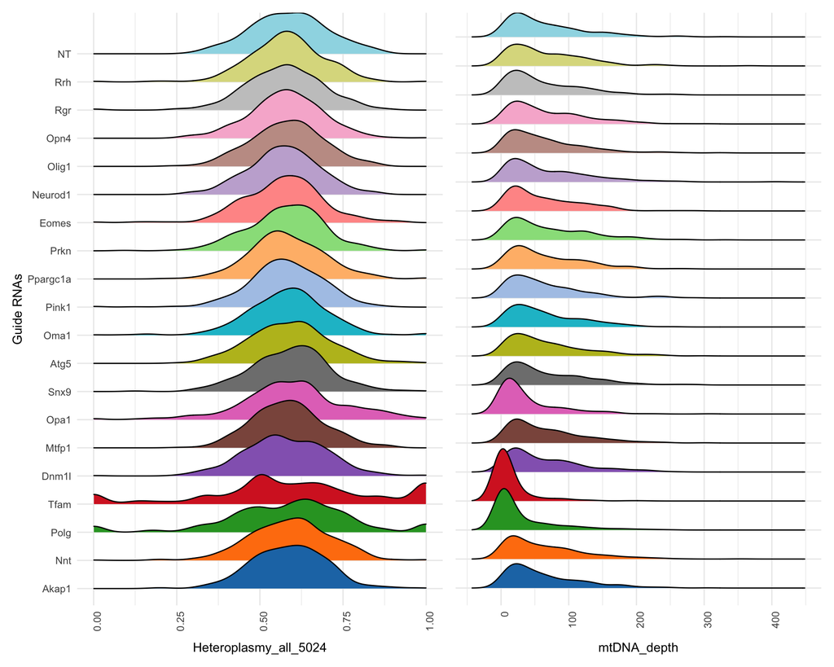

Figure 1: Ridge plots showing heteroplasmy distributions across gRNAs. TFAM, POLG, and OPA1 show broader distributions.

### Applying mtDNA depth cutoff > 20

In-silico modelling of heteroplasmy calling based on sub-sampling of a simulated heteroplasmic mtDNA population suggested an increase in sampling noise at mtDNA depths < 20. However, the most dramatic perturbations (TFAM, POLG, OPA1) also exhibit significant mtDNA copy number reduction.

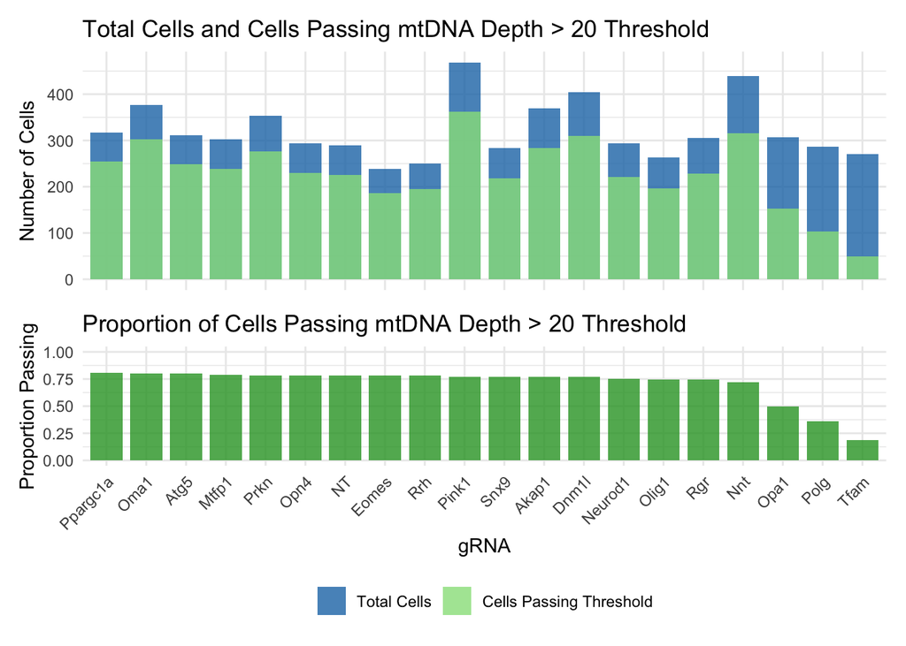

Figure 2: Number of cells and proportion passing mtDNA depth > 20 threshold by gRNA. Top panel shows total cells (blue) and cells passing threshold (green). Bottom panel shows proportion passing threshold. TFAM, POLG, and OPA1 show the largest drops in cells passing threshold.

The gRNAs associated with mtDNA copy number reduction also show the greatest drop of cells passing the mtDNA depth > 20 threshold.

| gRNA | Total Cells | Cells Passing Threshold | Proportion Passing |
| --- | --- | --- | --- |
| `Tfam` | 271 | 50 | 0.18 |
| `Polg` | 287 | 103 | 0.36 |
| `Opa1` | 307 | 153 | 0.5 |

Applying a read depth threshold increases the accuracy of the per-cell heteroplasmy calls, which is an important consideration for downstream analyses that aim to identify subtle shifts in mean heteroplasmy. However, in the context of gene perturbations that result in a depletion of mtDNA copy number, it also risks losing genuine biological signal by excluding the cells with the most pronounced perturbations.